# 0. Visualisation de chemins

## 2.2. Comportement par rapport au nombre de sommets : étude du comportement moyen

Récupération du temps moyen.

Ajustement du modèle linéaire de $\log(temps.moy)^2$ en fonction de $n$.

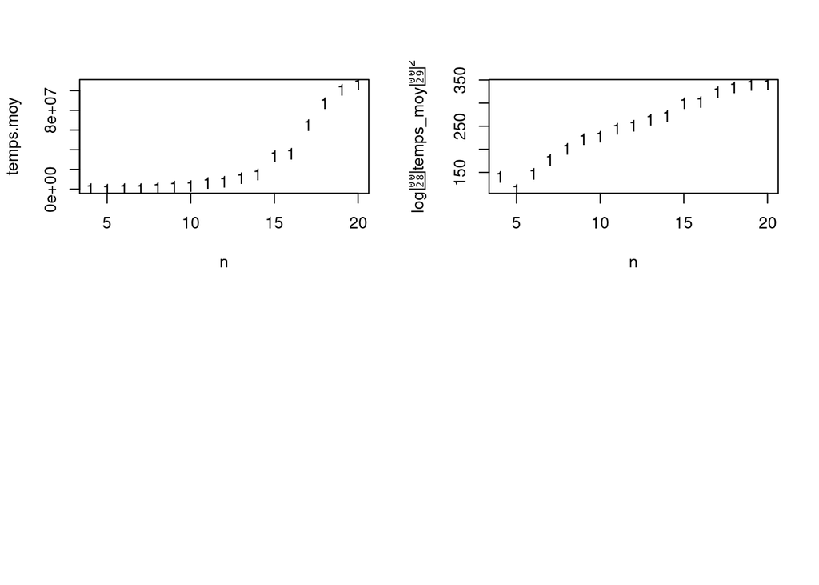

```r
seqn <- seq(4,20,1)
times <- 10
temps <- matrix(0,nrow=length(seqn),ncol=times)


for (i in 1:length(seqn)) {
  temps[i,]<- t(microbenchmark(TSPsolve(couts, method = 'branch'),
  times = times,
  setup = { n <- seqn[i]
            couts <- distance(cbind(x = runif(n), y = runif(n)))}
  )$time)
}
temps_moy <- rowMeans(temps)
par(mfrow=c(2,2)) # 2 graphiques sur 1 ligne
# par(mfrow=c(1,2)) # 2 graphiques sur 1 ligne
matplot(seqn, temps_moy, xlab='n', ylab='temps.moy')
matplot(seqn, log(temps_moy)^2, xlab='n', ylab=expression(log(temps_moy)^2))
#le temps de calcul évolue de manière exponentielle en fonction de n, nous allons donc plutôt utiliser le gogarithme du temps de calcul pour se ramener à une répartition linéaire
```

Ajustement du modèle linéaire de $\log(temps)^2$ en fonction de $n$.

```r
vect_temps_moy <- log(as.vector(temps_moy))^2
vect_dim_moy <- rep(seqn,1)
temps_moy.lm <- lm(vect_temps_moy ~ vect_dim_moy)
summary(temps_moy.lm)
```

```
##
## Call:
## lm(formula = vect_temps_moy ~ vect_dim_moy)
##
## Residuals:
##     Min      1Q  Median      3Q     Max
## -34.448  -3.098   2.766   8.255  17.788
##
## Coefficients:
##              Estimate Std. Error t value Pr(>|t|)
## (Intercept)   77.1502     8.6157   8.955 2.09e-07 ***
## vect_dim_moy  14.1981     0.6647  21.360 1.21e-12 ***
## ---
## Signif. codes:  0 '***' 0.001 '**' 0.01 '*' 0.05 '.' 0.1 ' ' 1
##
## Residual standard error: 13.43 on 15 degrees of freedom
## Multiple R-squared:  0.9682, Adjusted R-squared:  0.966
## F-statistic: 456.2 on 1 and 15 DF,  p-value: 1.214e-12
```

Etude graphique des analyse de résidus.

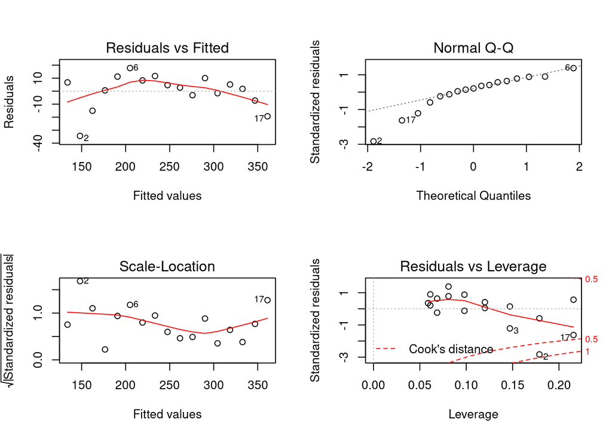

```r
par(mfrow=c(2,2)) # 4 graphiques, sur 2 lignes et 2 colonnes
plot(temps_moy.lm)
```

```r
shapiro.test(residuals(temps_moy.lm))
```

```
##
##  Shapiro-Wilk normality test
##
## data:  residuals(temps_moy.lm)
## W = 0.89819, p-value = 0.06335
```

```r
#
```

Analyse de la validité du modèle :

- pertinence des coefficients et du modèle,
- étude des hypothèses sur les résidus.

## 2.3. Comportement par rapport à la structure du graphe

Lecture du fichier ‘DonneesTSP.csv’.

Mise en uvre d’une sélection de variables pour ne garder que les variables pertinentes.

Analyse de la validité du modèle :

- pertinence des coefficients et du modèle,
- étude des hypothèses sur les résidus.

```r
data.graph <- data.frame(read.csv('Data/DonneesTSP.csv',header=TRUE,dec='.',sep=',',quote="\""))
# dataset_columns <- c("dim", "mean.long","mean.dist", "sd.dist", "mean.deg", "sd.deg", "diameter")
data.graph$dim <- sqrt(data.graph$dim)
temps_tsp.lm <- lm(log(tps) ~ ., data=data.graph)

summary(temps_tsp.lm)
```

```
##
## Call:
## lm(formula = log(tps) ~ ., data = data.graph)
##
## Residuals:
##      Min       1Q   Median       3Q      Max
## -0.78776 -0.15715  0.01542  0.17260  0.65036
##
## Coefficients:
##               Estimate Std. Error t value Pr(>|t|)
## (Intercept)  6.4903426  0.5450715  11.907  < 2e-16 ***
## dim          3.4191719  0.2391476  14.297  < 2e-16 ***
## mean.long   -4.8152962  0.7294055  -6.602 1.05e-08 ***
## mean.dist   -0.0020048  0.0010633  -1.886  0.06404 .
## sd.dist      0.0048105  0.0006652   7.231 8.55e-10 ***
## mean.deg    -0.1367369  0.0425459  -3.214  0.00208 **
## sd.deg       0.1399515  0.0872430   1.604  0.11376
## diameter    -0.0646816  0.1566329  -0.413  0.68107
## ---
## Signif. codes:  0 '***' 0.001 '**' 0.01 '*' 0.05 '.' 0.1 ' ' 1
##
## Residual standard error: 0.2912 on 62 degrees of freedom
## Multiple R-squared:  0.986,  Adjusted R-squared:  0.9844
## F-statistic: 622.6 on 7 and 62 DF,  p-value: < 2.2e-16
```

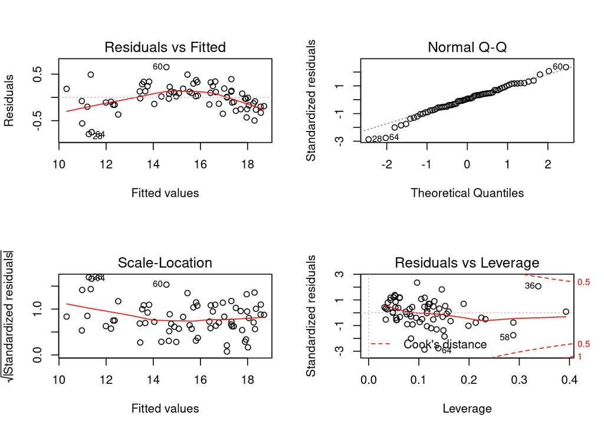

```r
par(mfrow=c(2,2)) # 4 graphiques, sur 2 lignes et 2 colonnes
plot(temps_tsp.lm)
```

```r
shapiro.test(residuals(temps_tsp.lm))
```

```
##
##  Shapiro-Wilk normality test
##
## data:  residuals(temps_tsp.lm)
## W = 0.98289, p-value = 0.455
```

```r
summary(step(temps_tsp.lm))
```

```
## Start:  AIC=-165.23
## log(tps) ~ dim + mean.long + mean.dist + sd.dist + mean.deg +
##     sd.deg + diameter
##
##             Df Sum of Sq     RSS      AIC
## - diameter   1    0.0145  5.2711 -167.038
## <none>                    5.2566 -165.230
## - sd.deg     1    0.2182  5.4748 -164.384
## - mean.dist  1    0.3014  5.5581 -163.327
## - mean.deg   1    0.8757  6.1324 -156.444
## - mean.long  1    3.6951  8.9517 -129.965
## - sd.dist    1    4.4335  9.6902 -124.417
## - dim        1   17.3311 22.5877  -65.176
##
## Step:  AIC=-167.04
## log(tps) ~ dim + mean.long + mean.dist + sd.dist + mean.deg +
##     sd.deg
##
##             Df Sum of Sq     RSS      AIC
## <none>                    5.2711 -167.038
## - sd.deg     1    0.2065  5.4776 -166.349
## - mean.dist  1    0.6554  5.9265 -160.835
## - mean.deg   1    0.9820  6.2531 -157.080
## - mean.long  1    3.8220  9.0931 -130.869
## - sd.dist    1    4.9133 10.1844 -122.935
## - dim        1   18.7788 24.0499  -62.785
```

```
##
## Call:
## lm(formula = log(tps) ~ dim + mean.long + mean.dist + sd.dist +
##     mean.deg + sd.deg, data = data.graph)
##
## Residuals:
##      Min       1Q   Median       3Q      Max
## -0.78246 -0.15445  0.00111  0.18027  0.63156
##
## Coefficients:
##               Estimate Std. Error t value Pr(>|t|)
## (Intercept)  6.3960078  0.4916227  13.010  < 2e-16 ***
## dim          3.4440771  0.2298893  14.981  < 2e-16 ***
## mean.long   -4.8548566  0.7183110  -6.759 5.25e-09 ***
## mean.dist   -0.0022837  0.0008160  -2.799  0.00680 **
## sd.dist      0.0048833  0.0006372   7.663 1.39e-10 ***
## mean.deg    -0.1408227  0.0411061  -3.426  0.00108 **
## sd.deg       0.1269156  0.0807943   1.571  0.12123
## ---
## Signif. codes:  0 '***' 0.001 '**' 0.01 '*' 0.05 '.' 0.1 ' ' 1
##
## Residual standard error: 0.2893 on 63 degrees of freedom
## Multiple R-squared:  0.9859, Adjusted R-squared:  0.9846
## F-statistic:   736 on 6 and 63 DF,  p-value: < 2.2e-16
```

```
## Start:  AIC=-165.23
## log(tps) ~ dim + mean.long + mean.dist + sd.dist + mean.deg +
##     sd.deg + diameter
##
##             Df Sum of Sq     RSS      AIC
## - diameter   1    0.0145  5.2711 -167.038
## <none>                    5.2566 -165.230
## - sd.deg     1    0.2182  5.4748 -164.384
## - mean.dist  1    0.3014  5.5581 -163.327
## - mean.deg   1    0.8757  6.1324 -156.444
## - mean.long  1    3.6951  8.9517 -129.965
## - sd.dist    1    4.4335  9.6902 -124.417
## - dim        1   17.3311 22.5877  -65.176
##
## Step:  AIC=-167.04
## log(tps) ~ dim + mean.long + mean.dist + sd.dist + mean.deg +
##     sd.deg
##
##             Df Sum of Sq     RSS      AIC
## <none>                    5.2711 -167.038
## - sd.deg     1    0.2065  5.4776 -166.349
## - mean.dist  1    0.6554  5.9265 -160.835
## - mean.deg   1    0.9820  6.2531 -157.080
## - mean.long  1    3.8220  9.0931 -130.869
## - sd.dist    1    4.9133 10.1844 -122.935
## - dim        1   18.7788 24.0499  -62.785
```

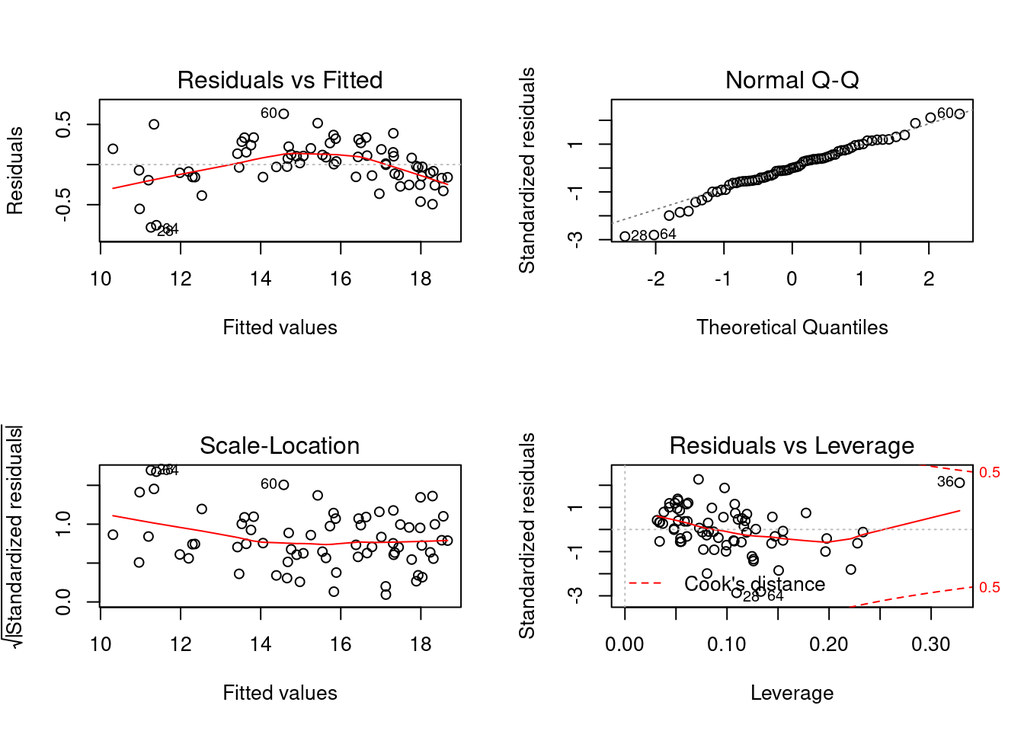

```r
par(mfrow=c(2,2)) # 4 graphiques, sur 2 lignes et 2 colonnes
plot(step(temps_tsp.lm))
```

```r
shapiro.test(residuals(step(temps_tsp.lm)))
```

```
## Start:  AIC=-165.23
## log(tps) ~ dim + mean.long + mean.dist + sd.dist + mean.deg +
##     sd.deg + diameter
##
##             Df Sum of Sq     RSS      AIC
## - diameter   1    0.0145  5.2711 -167.038
## <none>                    5.2566 -165.230
## - sd.deg     1    0.2182  5.4748 -164.384
## - mean.dist  1    0.3014  5.5581 -163.327
## - mean.deg   1    0.8757  6.1324 -156.444
## - mean.long  1    3.6951  8.9517 -129.965
## - sd.dist    1    4.4335  9.6902 -124.417
## - dim        1   17.3311 22.5877  -65.176
##
## Step:  AIC=-167.04
## log(tps) ~ dim + mean.long + mean.dist + sd.dist + mean.deg +
##     sd.deg
##
##             Df Sum of Sq     RSS      AIC
## <none>                    5.2711 -167.038
## - sd.deg     1    0.2065  5.4776 -166.349
## - mean.dist  1    0.6554  5.9265 -160.835
## - mean.deg   1    0.9820  6.2531 -157.080
## - mean.long  1    3.8220  9.0931 -130.869
## - sd.dist    1    4.9133 10.1844 -122.935
## - dim        1   18.7788 24.0499  -62.785
```

```
##
##  Shapiro-Wilk normality test
##
## data:  residuals(step(temps_tsp.lm))
## W = 0.98094, p-value = 0.3641
```